# Orca Whistles First Look

Abraham Borker

3/16/2016

These are really fun to listen to! This approach really works best with isolated clips. Alot of the recordings contain long periods of silence and noise, so I can’t really automate the measurements. If you have some isolated sounds, or can use raven to do some noise reduction and editing, this gives you a sense of what seewave can help you do. It’s not a magic bullet though.

```r
bd<-getwd()
setwd(paste(bd,"/firstset/", sep=""))
library(seewave)
library(tuneR)
```

```r
library(RColorBrewer)
library(ggplot2)
filenames<-dir(pattern=".wav")
#filenames
#file.info(filenames)
a<-readWave(filenames[5])
a<-readWave("pu146.071608.240.326wh.wav")
b<-readWave("pu146.071608.240.326whnr.wav")
#a
f <-a@samp.rate
```

Here’s a spectrogram of pu146.071608.240.326wh.wav

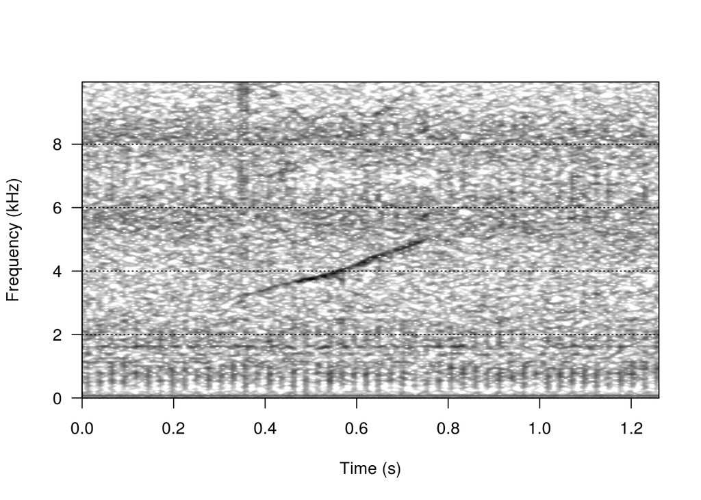

```r
spectro(a, f=f, ovlp=75, zp=8, palette=reverse.gray.colors.2, scale=FALSE)
```

And tracking the dominant frequency

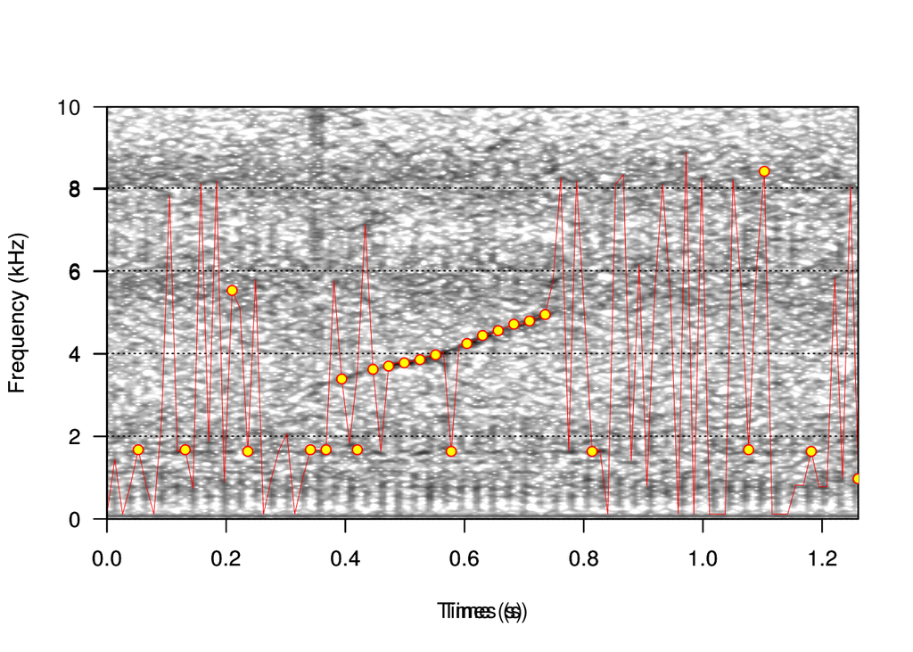

```r
spectro(a, f=f, ovlp=75, zp=8, palette=reverse.gray.colors.2, scale=FALSE)
par(new=TRUE)
dfreq(a, f=f, ovlp=50, threshold=6, type="l", col="red", lwd=.5)
res <- dfreq(a, f, clip = 0.3, plot = FALSE)
points(res, col = "red", bg = "yellow", pch = 21)
```

It get’s alot better with some noise reduction. I used the builtin tool in audacity in this case and resaved the file.

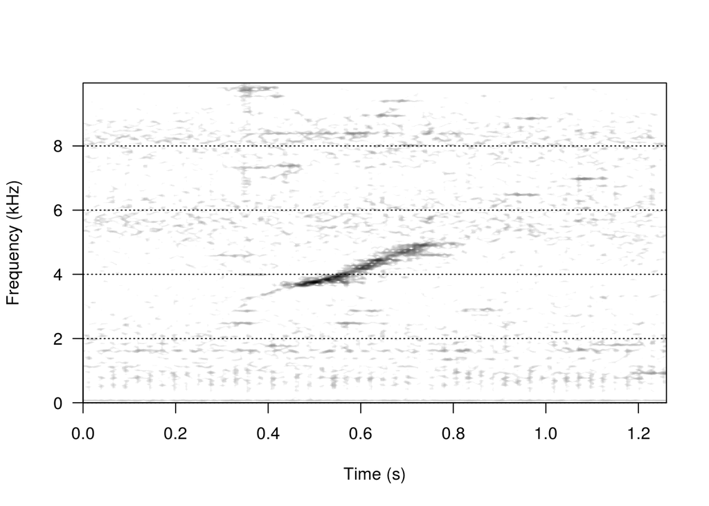

```r
f <-b@samp.rate
spectro(b, f=f, ovlp=75, zp=8, palette=reverse.gray.colors.2, scale=FALSE)
```

And tracking the dominant frequency

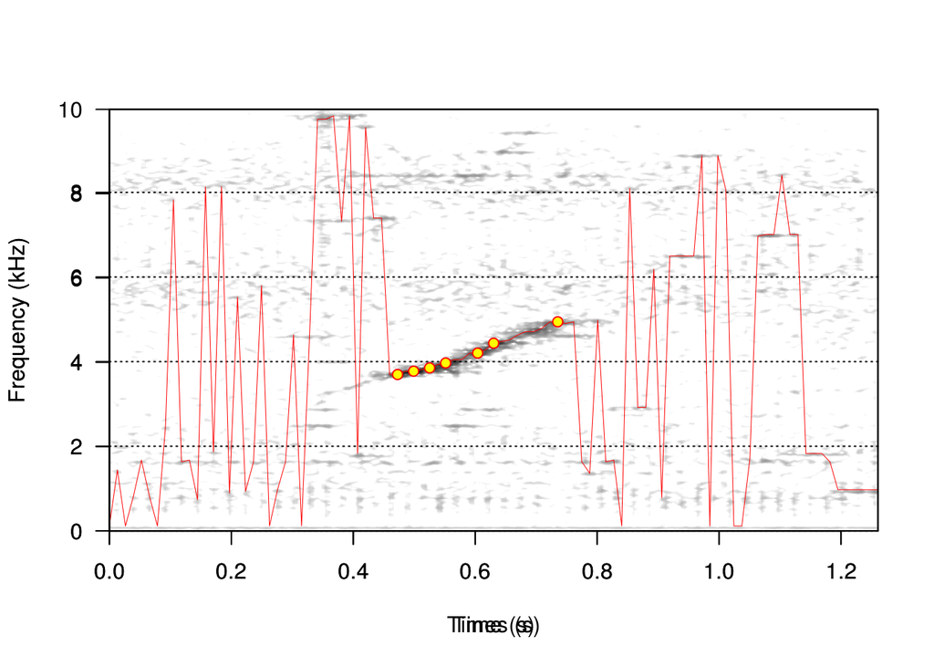

```r
spectro(b, f=f, ovlp=75, zp=8, palette=reverse.gray.colors.2, scale=FALSE)
par(new=TRUE)
dfreq(b, f=f, ovlp=50, threshold=6, type="l", col="red", lwd=.5)
res <- dfreq(b, f, clip = 0.3, plot = FALSE)
points(res, col = "red", bg = "yellow", pch = 21)
```

Those values have a distribution

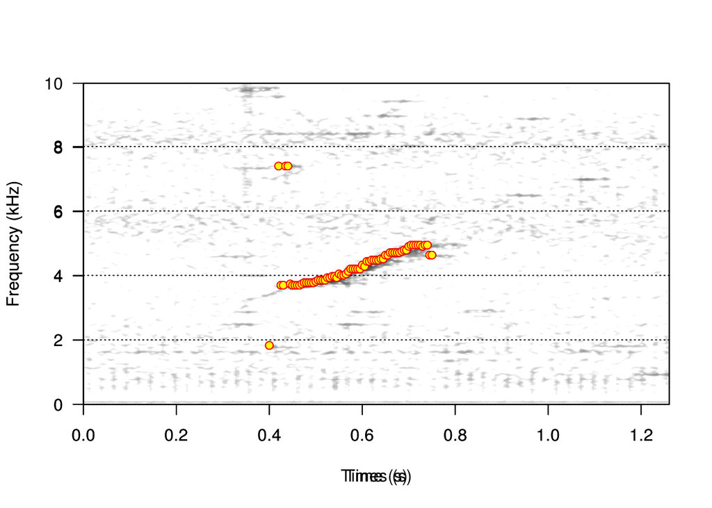

```r
spectro(b, f=f, ovlp=75, zp=8, palette=reverse.gray.colors.2, scale=FALSE)
par(new=TRUE)
res<-dfreq(b, f, at=seq(0.4, 0.75, by=0.005), threshold=5, clip=.1)
points(res, col = "red", bg = "yellow", pch = 21)
```

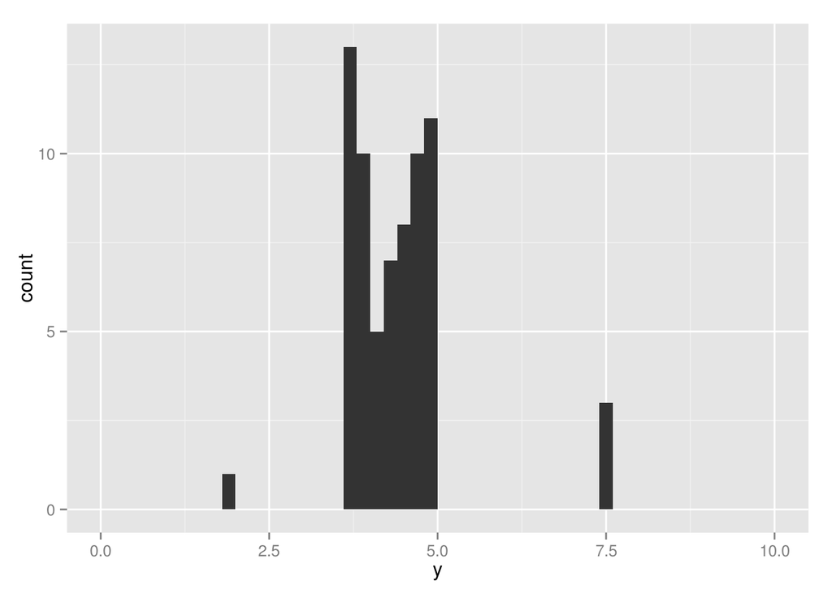

```r
res2<-data.frame(res)
ggplot(res2, aes(y))+geom_histogram(binwidth = 0.2)+xlim(0,10)
```

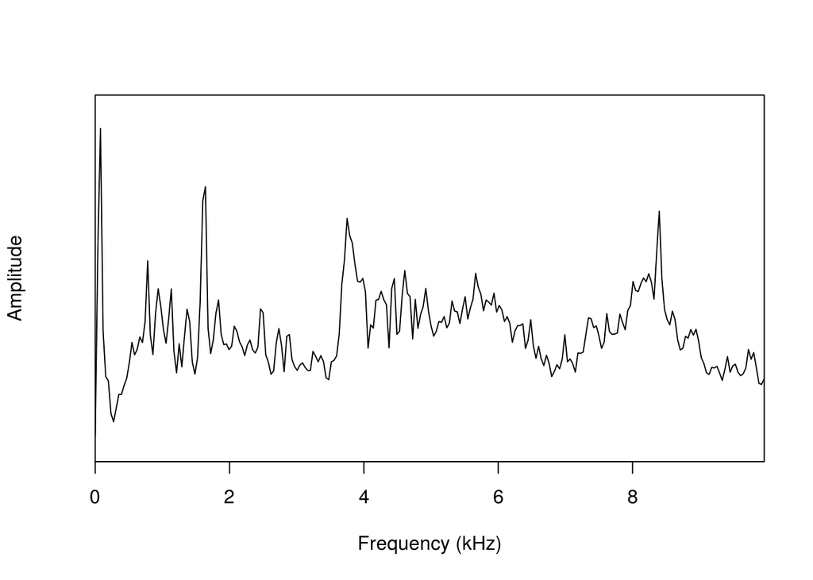

```r
#?dfreq
#??histogram
meanspec(b)
```

Now let’s load a second file and a noise reduced version, again using audacity

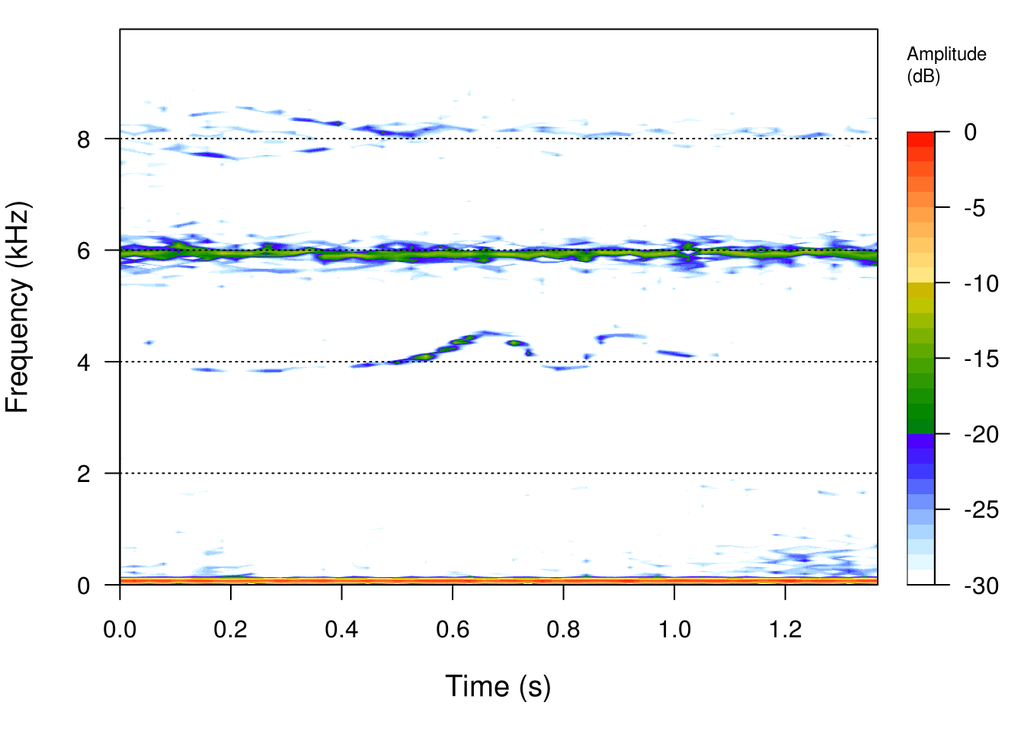

```r
setwd(paste(bd,"/firstset/", sep=""))
c<-readWave("pu146.071608.640.716whis.wav")
spectro(c)
```

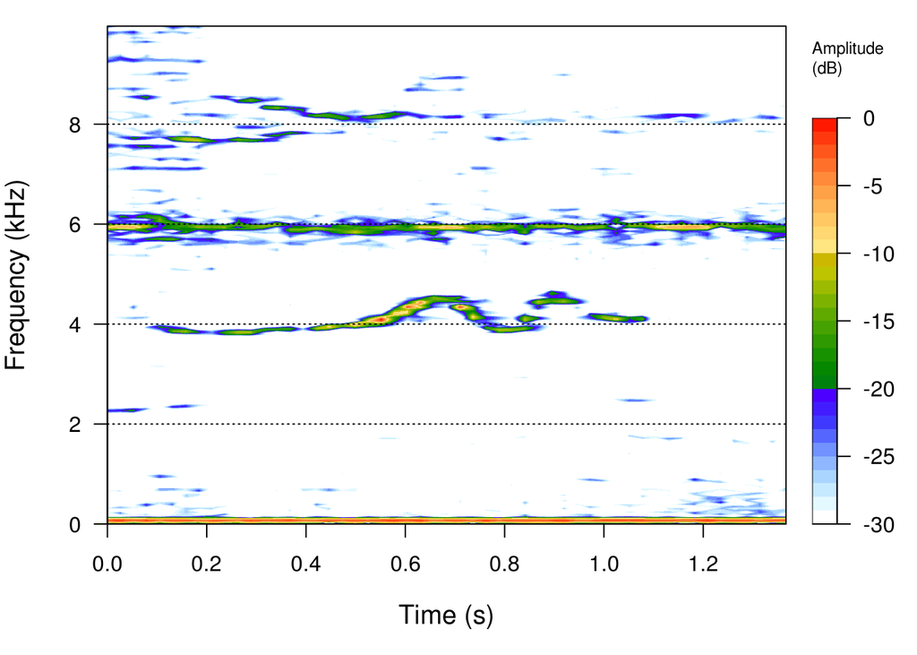

```r
d<-readWave("pu146.071808.1640.46whisnr.wav")
spectro(d)
```

When I try to measure dominant frequency see how background noise (in this case low frequency) tricks it up, a solution would be going to each clip and applying bandpass filters. I think you can do this relatively quickly in Raven, a bit cumbersome in R using ffilter

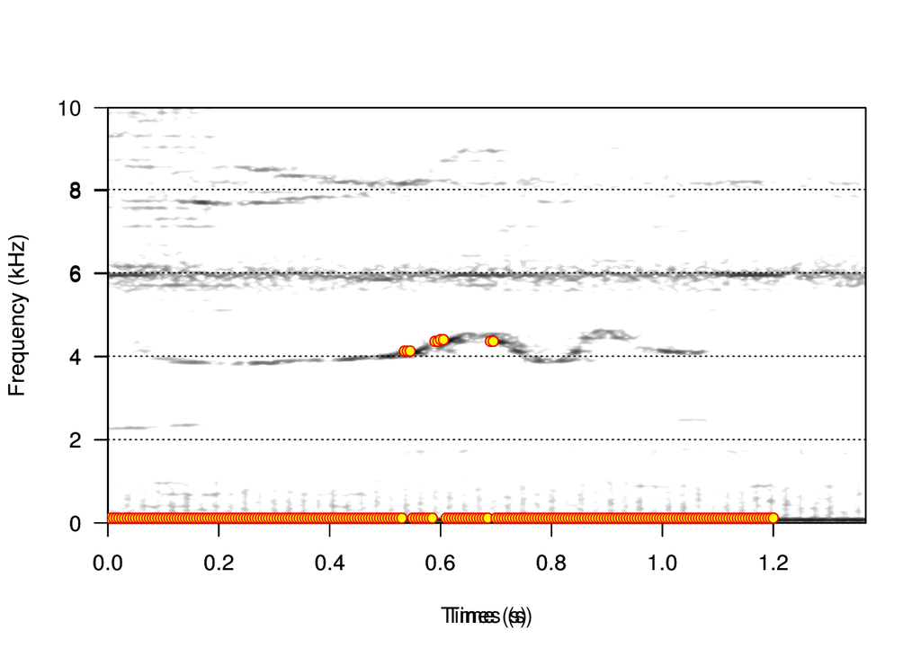

```r
spectro(d, f=f, ovlp=75, zp=8, palette=reverse.gray.colors.2, scale=FALSE)
par(new=TRUE)
res<-dfreq(d, f, at=seq(0.0, 1.2, by=0.005), threshold=5, clip=.1)
points(res, col = "red", bg = "yellow", pch = 21)
```

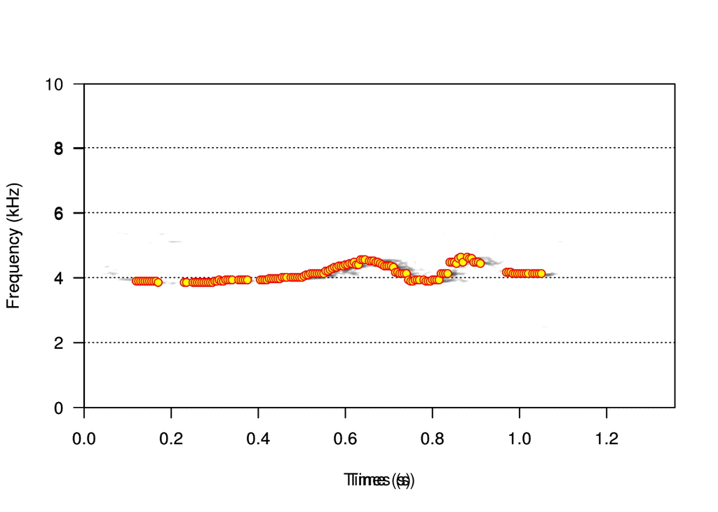

```r
#res2<-data.frame(res)
#ggplot(res2, aes(y))+geom_histogram(binwidth = 0.2)+xlim(0,10)
d<-ffilter(d,f=f,from=2500,to=5500)
spectro(d, f=f, ovlp=75, zp=8, palette=reverse.gray.colors.2, scale=FALSE)
par(new=TRUE)
res<-dfreq(d, f, at=seq(0.0, 1.2, by=0.005), threshold=5, clip=.1)
points(res, col = "red", bg = "yellow", pch = 21)
```

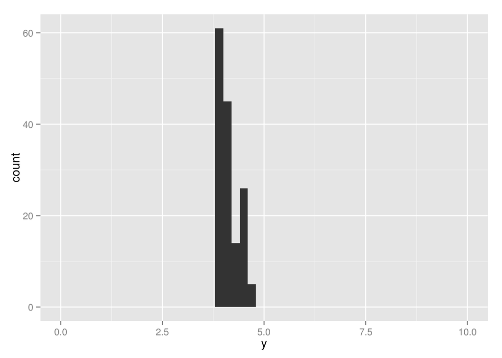

```r
res3<-data.frame(res)
ggplot(res3, aes(y))+geom_histogram(binwidth = 0.2)+xlim(0,10)
```

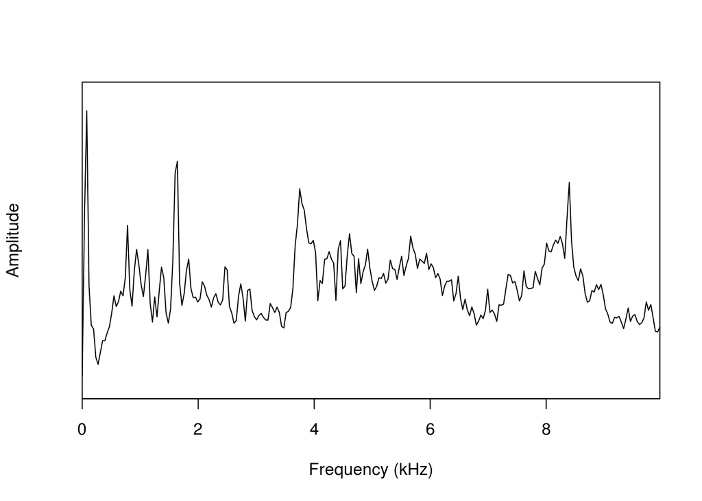

```r
#?dfreq
#??histogram
meanspec(b)
```

Now we can compate the two spectra directly

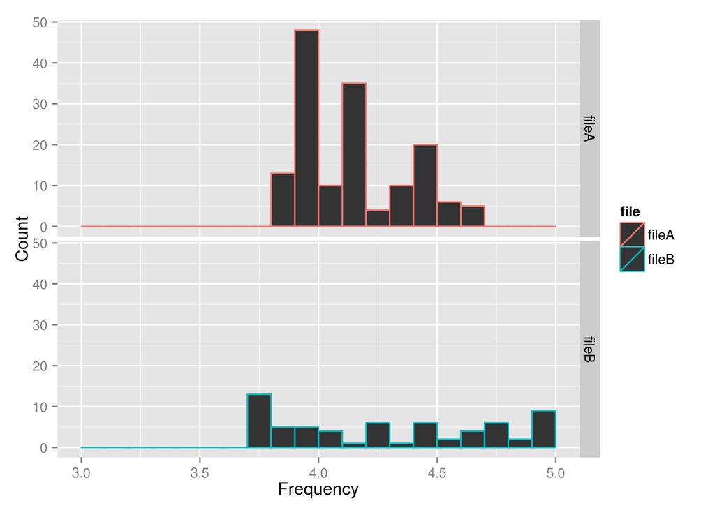

```r
res3$file<-c("fileA")
res2$file<-c("fileB")
both<-rbind(res3,res2)
ggplot(both, aes(y, color=file))+geom_histogram(binwidth = 0.1)+xlim(0,10)+facet_grid(file~.)+xlab("Frequency")+ylab("Count")+xlim(3,5)
```

If the recordings were all prescreened you could get a distribtion of dominan frequencies for each whistle and then compare them all using a distance matrix and PVA to get a bivariate plot showing how different each area’s calls are.

Sorry I wasn’t able to get to that spot, there’s probably a full day of prescreening clips that would need to be done.

I hope this helps and illustrates what’s possible using R and seewave.

Cheers, Abe